# Human Activity Recognition - Weight Lifting Exercise Class Clasification

Unai Zorrilla Castro

April 1, 2016

# Synopsis

Using devices such as Jawbone Up, Nike FuelBand, and Fitbit it is now possible to collect a large amount of data about personal activity relatively inexpensively. These type of devices are part of the quantified self movement - a group of enthusiasts who take measurements about themselves regularly to improve their health, to find patterns in their behavior, or because they are tech geeks. One thing that people regularly do is quantify how much of a particular activity they do, but they rarely quantify how well they do it. In this project, your goal will be to use data from accelerometers on the belt, forearm, arm, and dumbell of 6 participants. They were asked to perform barbell lifts correctly and incorrectly in 5 different ways

## Data Sets

Velloso, E.; Bulling, A.; Gellersen, H.; Ugulino, W.; Fuks, H. Qualitative Activity Recognition of Weight Lifting Exercises. Proceedings of 4th International Conference in Cooperation with SIGCHI (Augmented Human ’13) . Stuttgart, Germany: ACM SIGCHI, 2013.

The training data for this project are available here:

https://d396qusza40orc.cloudfront.net/predmachlearn/pml-training.csv

The test data are available here:

https://d396qusza40orc.cloudfront.net/predmachlearn/pml-testing.csv

# Objectives

By processing data gathered from accelerometers on the belt, forearm, arm, and dumbell of the participants in a machine learning algorithm, the question **is can the appropriate activity quality (class A-E) be predicted?**

# Cleaning and Data transformation

## Download and cleaning data sets

Our first task is download data and examining the content of the traning and testing data. The next script show the code to download experiment data sets.

```r
trainingUrl<-"https://d396qusza40orc.cloudfront.net/predmachlearn/pml-training.csv"
testingUrl <-"https://d396qusza40orc.cloudfront.net/predmachlearn/pml-testing.csv"

#download.file(trainingUrl,"./datasets/training.csv")
#download.file(testingUrl,"./datasets/testing.csv")

trainingds <-read.csv("./datasets/training.csv",stringsAsFactors = T,na.strings = c("NA",""),header = TRUE)

testingds <-read.csv("./datasets/testing.csv",stringsAsFactors = T,na.strings = c("NA",""),header = TRUE)

summary(trainingds)
```

```
##        X            user_name    raw_timestamp_part_1 raw_timestamp_part_2
##  Min.   :    1   adelmo  :3892   Min.   :1.322e+09    Min.   :   294
##  1st Qu.: 4906   carlitos:3112   1st Qu.:1.323e+09    1st Qu.:252912
##  Median : 9812   charles :3536   Median :1.323e+09    Median :496380
##  Mean   : 9812   eurico  :3070   Mean   :1.323e+09    Mean   :500656
##  3rd Qu.:14717   jeremy  :3402   3rd Qu.:1.323e+09    3rd Qu.:751891
##  Max.   :19622   pedro   :2610   Max.   :1.323e+09    Max.   :998801
##
##           cvtd_timestamp  new_window    num_window      roll_belt
##  28/11/2011 14:14: 1498   no :19216   Min.   :  1.0   Min.   :-28.90
##  05/12/2011 11:24: 1497   yes:  406   1st Qu.:222.0   1st Qu.:  1.10
##  30/11/2011 17:11: 1440               Median :424.0   Median :113.00
##  05/12/2011 11:25: 1425               Mean   :430.6   Mean   : 64.41
##  02/12/2011 14:57: 1380               3rd Qu.:644.0   3rd Qu.:123.00
##  02/12/2011 13:34: 1375               Max.   :864.0   Max.   :162.00
##  (Other)         :11007
##    pitch_belt          yaw_belt       total_accel_belt kurtosis_roll_belt
##  Min.   :-55.8000   Min.   :-180.00   Min.   : 0.00    #DIV/0!  :   10
##  1st Qu.:  1.7600   1st Qu.: -88.30   1st Qu.: 3.00    -1.908453:    2
##  Median :  5.2800   Median : -13.00   Median :17.00    -0.016850:    1
##  Mean   :  0.3053   Mean   : -11.21   Mean   :11.31    -0.021024:    1
##  3rd Qu.: 14.9000   3rd Qu.:  12.90   3rd Qu.:18.00    -0.025513:    1
##  Max.   : 60.3000   Max.   : 179.00   Max.   :29.00    (Other)  :  391
##                                                        NA's     :19216
##  kurtosis_picth_belt kurtosis_yaw_belt skewness_roll_belt
##  #DIV/0!  :   32     #DIV/0!:  406     #DIV/0!  :    9
##  47.000000:    4     NA's   :19216     0.000000 :    4
##  -0.150950:    3                       0.422463 :    2
##  -0.684748:    3                       -0.003095:    1
##  -1.750749:    3                       -0.010002:    1
##  (Other)  :  361                       (Other)  :  389
##  NA's     :19216                       NA's     :19216
##  skewness_roll_belt.1 skewness_yaw_belt max_roll_belt     max_picth_belt
##  #DIV/0!  :   32      #DIV/0!:  406     Min.   :-94.300   Min.   : 3.00
##  0.000000 :    4      NA's   :19216     1st Qu.:-88.000   1st Qu.: 5.00
##  -2.156553:    3                        Median : -5.100   Median :18.00
##  -3.072669:    3                        Mean   : -6.667   Mean   :12.92
##  -6.324555:    3                        3rd Qu.: 18.500   3rd Qu.:19.00
##  (Other)  :  361                        Max.   :180.000   Max.   :30.00
##  NA's     :19216                        NA's   :19216     NA's   :19216
```

[output cut: 313 more lines]

```
##  Min.   :-446.00   Min.   :-1280.0   Min.   :-896.0   Min.   :-973.0
##  1st Qu.:-182.00   1st Qu.: -616.0   1st Qu.:   2.0   1st Qu.: 191.0
##  Median : -39.00   Median : -378.0   Median : 591.0   Median : 511.0
##  Mean   : -55.29   Mean   : -312.6   Mean   : 380.1   Mean   : 393.6
##  3rd Qu.:  26.00   3rd Qu.:  -73.0   3rd Qu.: 737.0   3rd Qu.: 653.0
##  Max.   : 291.00   Max.   :  672.0   Max.   :1480.0   Max.   :1090.0
##
##  classe
##  A:5580
##  B:3797
##  C:3422
##  D:3216
##  E:3607
##
##
```

Reading the summary of our datasets, a lot of columns contains many NA values and also, exist, the first seven, not interested columns in our classification experiment. The next script remove all unnecesary columns and columns with excesive NA’s values.

```r
trainingds<-trainingds[,-(1:7)]
testingds<-testingds[,-(1:7)]

countOfNAs <- function(x) {
  as.vector(apply(x, 2, function(x) length(which(!is.na (x))))) }

columnsToRemove <- countOfNAs(trainingds)<nrow(trainingds)

drop<-c()
for(index in 1:length(columnsToRemove)){
  if(columnsToRemove[index]){
    drop<-c(drop,index)
  }
}

sanitized_trainingds<-trainingds[,-drop]
sanitized_testingds<-testingds[,-drop]
sanitized_testingds<-sanitized_testingds[,-53]

summary(sanitized_trainingds)
```

```
##    roll_belt        pitch_belt          yaw_belt       total_accel_belt
##  Min.   :-28.90   Min.   :-55.8000   Min.   :-180.00   Min.   : 0.00
##  1st Qu.:  1.10   1st Qu.:  1.7600   1st Qu.: -88.30   1st Qu.: 3.00
##  Median :113.00   Median :  5.2800   Median : -13.00   Median :17.00
##  Mean   : 64.41   Mean   :  0.3053   Mean   : -11.21   Mean   :11.31
##  3rd Qu.:123.00   3rd Qu.: 14.9000   3rd Qu.:  12.90   3rd Qu.:18.00
##  Max.   :162.00   Max.   : 60.3000   Max.   : 179.00   Max.   :29.00
##   gyros_belt_x        gyros_belt_y       gyros_belt_z
##  Min.   :-1.040000   Min.   :-0.64000   Min.   :-1.4600
##  1st Qu.:-0.030000   1st Qu.: 0.00000   1st Qu.:-0.2000
##  Median : 0.030000   Median : 0.02000   Median :-0.1000
##  Mean   :-0.005592   Mean   : 0.03959   Mean   :-0.1305
##  3rd Qu.: 0.110000   3rd Qu.: 0.11000   3rd Qu.:-0.0200
##  Max.   : 2.220000   Max.   : 0.64000   Max.   : 1.6200
##   accel_belt_x       accel_belt_y     accel_belt_z     magnet_belt_x
##  Min.   :-120.000   Min.   :-69.00   Min.   :-275.00   Min.   :-52.0
##  1st Qu.: -21.000   1st Qu.:  3.00   1st Qu.:-162.00   1st Qu.:  9.0
##  Median : -15.000   Median : 35.00   Median :-152.00   Median : 35.0
##  Mean   :  -5.595   Mean   : 30.15   Mean   : -72.59   Mean   : 55.6
##  3rd Qu.:  -5.000   3rd Qu.: 61.00   3rd Qu.:  27.00   3rd Qu.: 59.0
##  Max.   :  85.000   Max.   :164.00   Max.   : 105.00   Max.   :485.0
##  magnet_belt_y   magnet_belt_z       roll_arm         pitch_arm
##  Min.   :354.0   Min.   :-623.0   Min.   :-180.00   Min.   :-88.800
##  1st Qu.:581.0   1st Qu.:-375.0   1st Qu.: -31.77   1st Qu.:-25.900
##  Median :601.0   Median :-320.0   Median :   0.00   Median :  0.000
##  Mean   :593.7   Mean   :-345.5   Mean   :  17.83   Mean   : -4.612
##  3rd Qu.:610.0   3rd Qu.:-306.0   3rd Qu.:  77.30   3rd Qu.: 11.200
##  Max.   :673.0   Max.   : 293.0   Max.   : 180.00   Max.   : 88.500
##     yaw_arm          total_accel_arm  gyros_arm_x        gyros_arm_y
##  Min.   :-180.0000   Min.   : 1.00   Min.   :-6.37000   Min.   :-3.4400
##  1st Qu.: -43.1000   1st Qu.:17.00   1st Qu.:-1.33000   1st Qu.:-0.8000
##  Median :   0.0000   Median :27.00   Median : 0.08000   Median :-0.2400
##  Mean   :  -0.6188   Mean   :25.51   Mean   : 0.04277   Mean   :-0.2571
##  3rd Qu.:  45.8750   3rd Qu.:33.00   3rd Qu.: 1.57000   3rd Qu.: 0.1400
##  Max.   : 180.0000   Max.   :66.00   Max.   : 4.87000   Max.   : 2.8400
##   gyros_arm_z       accel_arm_x       accel_arm_y      accel_arm_z
##  Min.   :-2.3300   Min.   :-404.00   Min.   :-318.0   Min.   :-636.00
##  1st Qu.:-0.0700   1st Qu.:-242.00   1st Qu.: -54.0   1st Qu.:-143.00
##  Median : 0.2300   Median : -44.00   Median :  14.0   Median : -47.00
##  Mean   : 0.2695   Mean   : -60.24   Mean   :  32.6   Mean   : -71.25
```

[output cut: 50 more lines]

```
##  Max.   :311.00000   Max.   :231.0000   Max.   : 477.00   Max.   : 923.0
##  accel_forearm_z   magnet_forearm_x  magnet_forearm_y magnet_forearm_z
##  Min.   :-446.00   Min.   :-1280.0   Min.   :-896.0   Min.   :-973.0
##  1st Qu.:-182.00   1st Qu.: -616.0   1st Qu.:   2.0   1st Qu.: 191.0
##  Median : -39.00   Median : -378.0   Median : 591.0   Median : 511.0
##  Mean   : -55.29   Mean   : -312.6   Mean   : 380.1   Mean   : 393.6
##  3rd Qu.:  26.00   3rd Qu.:  -73.0   3rd Qu.: 737.0   3rd Qu.: 653.0
##  Max.   : 291.00   Max.   :  672.0   Max.   :1480.0   Max.   :1090.0
##  classe
##  A:5580
##  B:3797
##  C:3422
##  D:3216
##  E:3607
##
```

Another test to perform in this initial data is check the variability of values in each feature of our data set. For this, the nearZeroVar function from caret packages is performed.

```r
nzv<-nearZeroVar(sanitized_trainingds,saveMetrics = T)
nzv
```

```
##                      freqRatio percentUnique zeroVar   nzv
## roll_belt             1.101904     6.7781062   FALSE FALSE
## pitch_belt            1.036082     9.3772296   FALSE FALSE
## yaw_belt              1.058480     9.9734991   FALSE FALSE
## total_accel_belt      1.063160     0.1477933   FALSE FALSE
## gyros_belt_x          1.058651     0.7134849   FALSE FALSE
## gyros_belt_y          1.144000     0.3516461   FALSE FALSE
## gyros_belt_z          1.066214     0.8612782   FALSE FALSE
## accel_belt_x          1.055412     0.8357966   FALSE FALSE
## accel_belt_y          1.113725     0.7287738   FALSE FALSE
## accel_belt_z          1.078767     1.5237998   FALSE FALSE
## magnet_belt_x         1.090141     1.6664968   FALSE FALSE
## magnet_belt_y         1.099688     1.5187035   FALSE FALSE
## magnet_belt_z         1.006369     2.3290184   FALSE FALSE
## roll_arm             52.338462    13.5256345   FALSE FALSE
## pitch_arm            87.256410    15.7323412   FALSE FALSE
## yaw_arm              33.029126    14.6570176   FALSE FALSE
## total_accel_arm       1.024526     0.3363572   FALSE FALSE
## gyros_arm_x           1.015504     3.2769341   FALSE FALSE
## gyros_arm_y           1.454369     1.9162165   FALSE FALSE
## gyros_arm_z           1.110687     1.2638875   FALSE FALSE
## accel_arm_x           1.017341     3.9598410   FALSE FALSE
## accel_arm_y           1.140187     2.7367241   FALSE FALSE
## accel_arm_z           1.128000     4.0362858   FALSE FALSE
## magnet_arm_x          1.000000     6.8239731   FALSE FALSE
## magnet_arm_y          1.056818     4.4439914   FALSE FALSE
## magnet_arm_z          1.036364     6.4468454   FALSE FALSE
## roll_dumbbell         1.022388    84.2065029   FALSE FALSE
## pitch_dumbbell        2.277372    81.7449801   FALSE FALSE
## yaw_dumbbell          1.132231    83.4828254   FALSE FALSE
## total_accel_dumbbell  1.072634     0.2191418   FALSE FALSE
## gyros_dumbbell_x      1.003268     1.2282132   FALSE FALSE
## gyros_dumbbell_y      1.264957     1.4167771   FALSE FALSE
## gyros_dumbbell_z      1.060100     1.0498420   FALSE FALSE
## accel_dumbbell_x      1.018018     2.1659362   FALSE FALSE
## accel_dumbbell_y      1.053061     2.3748853   FALSE FALSE
## accel_dumbbell_z      1.133333     2.0894914   FALSE FALSE
## magnet_dumbbell_x     1.098266     5.7486495   FALSE FALSE
## magnet_dumbbell_y     1.197740     4.3012945   FALSE FALSE
## magnet_dumbbell_z     1.020833     3.4451126   FALSE FALSE
## roll_forearm         11.589286    11.0895933   FALSE FALSE
## pitch_forearm        65.983051    14.8557741   FALSE FALSE
## yaw_forearm          15.322835    10.1467740   FALSE FALSE
## total_accel_forearm   1.128928     0.3567424   FALSE FALSE
## gyros_forearm_x       1.059273     1.5187035   FALSE FALSE
## gyros_forearm_y       1.036554     3.7763735   FALSE FALSE
## gyros_forearm_z       1.122917     1.5645704   FALSE FALSE
## accel_forearm_x       1.126437     4.0464784   FALSE FALSE
## accel_forearm_y       1.059406     5.1116094   FALSE FALSE
## accel_forearm_z       1.006250     2.9558659   FALSE FALSE
## magnet_forearm_x      1.012346     7.7667924   FALSE FALSE
## magnet_forearm_y      1.246914     9.5403119   FALSE FALSE
## magnet_forearm_z      1.000000     8.5771073   FALSE FALSE
## classe                1.469581     0.0254816   FALSE FALSE
```

After observing variability in each feature, any new covariate need to be removed from data set.

## Prepare Training, Observation, Test data sets

After observing the lower number of observations on test data, 20, in this expermiment perform a new partition on training data to have some validation date for our experiments.

```r
trainIndexes<-createDataPartition(sanitized_trainingds$classe,p=3/4,list=F)

trainds<-sanitized_trainingds[trainIndexes,]
validationds<-sanitized_trainingds[-trainIndexes,]
testds<-sanitized_testingds

trainds$classe<-as.factor(trainds$classe)
validationds$classe<-as.factor(validationds$classe)
```

# Evaluating Models

## Classifcation Trees

The first model to evaluate is Classifcation Tree Method from *rpart* package and *caret*. After creating the model, a confussion matrix is created in order to evaluate the accuracy of the model on validation data set.

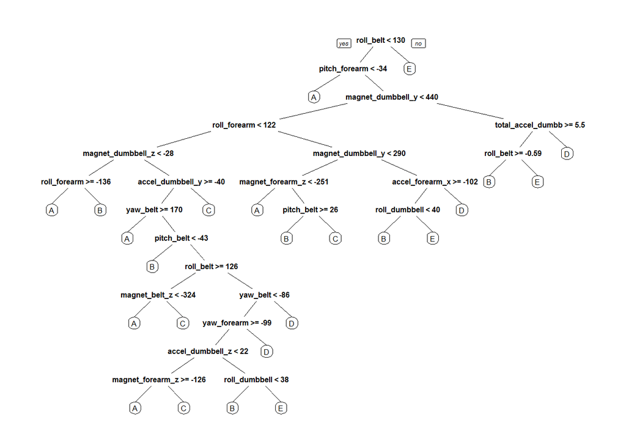

```r
fit1<-rpart(classe ~ .,data = trainds, method = "class")

rpart.plot(fit1)
```

```r
predictions <- predict(fit1,validationds,type = "class")

cfm<-confusionMatrix(predictions,validationds$classe)

cfm
```

```
## Confusion Matrix and Statistics
##
##           Reference
## Prediction    A    B    C    D    E
##          A 1214  134   10   33   10
##          B   56  571   48   63   69
##          C   28   92  689  122  108
##          D   54   77   50  506   54
##          E   43   75   58   80  660
##
## Overall Statistics
##
##                Accuracy : 0.7423
##                  95% CI : (0.7298, 0.7544)
##     No Information Rate : 0.2845
##     P-Value [Acc > NIR] : < 2.2e-16
##
##                   Kappa : 0.6741
##  Mcnemar's Test P-Value : < 2.2e-16
##
## Statistics by Class:
##
##                      Class: A Class: B Class: C Class: D Class: E
## Sensitivity            0.8703   0.6017   0.8058   0.6294   0.7325
## Specificity            0.9467   0.9403   0.9136   0.9427   0.9360
## Pos Pred Value         0.8665   0.7076   0.6631   0.6829   0.7205
## Neg Pred Value         0.9483   0.9077   0.9571   0.9284   0.9396
## Prevalence             0.2845   0.1935   0.1743   0.1639   0.1837
## Detection Rate         0.2476   0.1164   0.1405   0.1032   0.1346
## Detection Prevalence   0.2857   0.1646   0.2119   0.1511   0.1868
## Balanced Accuracy      0.9085   0.7710   0.8597   0.7860   0.8343
```

Two elements can be extracted for this results, accuracy with a value of 0.7422512 and Kappa with a value of 0.6740903. This overall accuracy is not bad, but Kappa value is a bit slower that ideal.

**Note: Kappa statistic adjust accuracy by accounting for the posibility of a correct prediction by change alone.**

## Random Forest

In order to improve results, other method to test is ensemble-based random forest:

```r
control<- trainControl(method="repeatedcv",number=4,allowParallel =TRUE,verbose=TRUE)
fit2 <- train(classe ~ .,
                      data=trainds,
                      method="rf",
                      preProcess=c("center","scale"),
                      trainControl=control)

predictions<-predict(fit2,validationds)
cfm<-confusionMatrix(predictions,validationds$classe)

cfm
```

```
## Confusion Matrix and Statistics
##
##           Reference
## Prediction    A    B    C    D    E
##          A 1395    6    0    0    0
##          B    0  940    9    0    0
##          C    0    3  845   13    0
##          D    0    0    1  791    3
##          E    0    0    0    0  898
##
## Overall Statistics
##
##                Accuracy : 0.9929
##                  95% CI : (0.9901, 0.995)
##     No Information Rate : 0.2845
##     P-Value [Acc > NIR] : < 2.2e-16
##
##                   Kappa : 0.991
##  Mcnemar's Test P-Value : NA
##
## Statistics by Class:
##
##                      Class: A Class: B Class: C Class: D Class: E
## Sensitivity            1.0000   0.9905   0.9883   0.9838   0.9967
## Specificity            0.9983   0.9977   0.9960   0.9990   1.0000
## Pos Pred Value         0.9957   0.9905   0.9814   0.9950   1.0000
## Neg Pred Value         1.0000   0.9977   0.9975   0.9968   0.9993
## Prevalence             0.2845   0.1935   0.1743   0.1639   0.1837
## Detection Rate         0.2845   0.1917   0.1723   0.1613   0.1831
## Detection Prevalence   0.2857   0.1935   0.1756   0.1621   0.1831
## Balanced Accuracy      0.9991   0.9941   0.9922   0.9914   0.9983
```

The Accuracy and Kappa statistic are:

```
** Accuracy:0.992863 **
** Kappa:0.990971 **
```

# Conclusion

The **out of sample error* is the error rate you get on new data set. In this case, after running predict on *validationds* the error is :

[output not shown]

The predictions for test dataset for both methods are:

```r
predict(fit1,testds,type="class")
```

```
##  1  2  3  4  5  6  7  8  9 10 11 12 13 14 15 16 17 18 19 20
##  B  A  E  D  A  C  D  A  A  A  C  E  C  A  E  E  A  B  B  B
## Levels: A B C D E
```

```r
predict(fit2,testds)
```

```
##  [1] B A B A A E D B A A B C B A E E A B B B
## Levels: A B C D E
```